# Question

# Univariate Analysis

### What is the structure of your dataset?

The red wine dataset is composed of 11 different chemical measurements and 1 quality assessment for each wine tested. In total, 1599 different wines have been studied and compose our observations. The first variable is an anonymized number that refers to the wine tested.

All the measurements are given in double. They consist in different types of concentration measurements given mainly in g/dm^3, or mg/dm^3.

There does not seem to be any missing value in the dataset.

### What is/are the main feature(s) of interest in your dataset?

Wine quality is the main feature we are interested in, as we want to discover which chemicals influence it.

### What other features in the dataset do you think will help support your investigation into your feature(s) of interest?

As a first guess, wine quality class could be to be influenced by:

- fixed acidity concentration
- volatile acidity concentration
- citric acid concentration
- residual sugars concentration
- sulfates concentration
- alcohol concentration

As the pH level is based on acidity level, I suspect it to be strongly correlated with acids concentrations.

### Did you create any new variables from existing variables in the dataset?

In order to display different frequency polygon curves for different wine quality classes, I added a new variable associating each observation to a wine class, based on the quality rate (less or equal than 4, between 5 and 6, more than 6).

Out of curiosity, I also added a new variable free.sulfur.dioxide.ratio to characterize the amount of free sulfur compared to the total amount of sulfur in the wine.

### Of the features you investigated, were there any unusual distributions? Did you perform any operations on the data to tidy, adjust, or change the form of the data? If so, why did you do this?

Each observed feature had a relatively normal distribution. In some cases, where there was not a lot of observations, the distribution was well-spread. I did not feel the use of adapting the distributions with log10 or square root transformations.

# Bivariate Plots Section

## Scatterplot Matrices

```r
names(df)
```

```
##  [1] "X"                         "fixed.acidity"
##  [3] "volatile.acidity"          "citric.acid"
##  [5] "residual.sugar"            "chlorides"
##  [7] "free.sulfur.dioxide"       "total.sulfur.dioxide"
##  [9] "density"                   "pH"
## [11] "sulphates"                 "alcohol"
## [13] "quality"                   "quality.class"
## [15] "quality.fac"               "free.sulfur.dioxide.ratio"
```

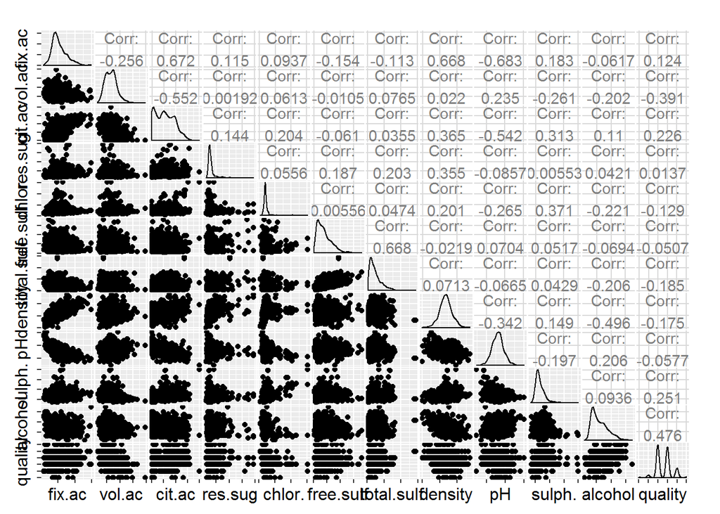

Strong correlations (|corr| > 0.45) appear between:

- fixed acidity and citric acidity
- fixed acidity and density
- fixed acidity and pH (negative correlation)
- volatile acidity and citric acidity
- citric acid and pH
- total sulfur dioxyde and free sulfur dioxyde
- alcohol and density

Looking at the wine quality rates box plots, this feature seems to be correlated with:

- the different types of acid concentration and pH
- alcohol concentration and density
- sulfates concentration

## Acidity concentration vs quality ratings

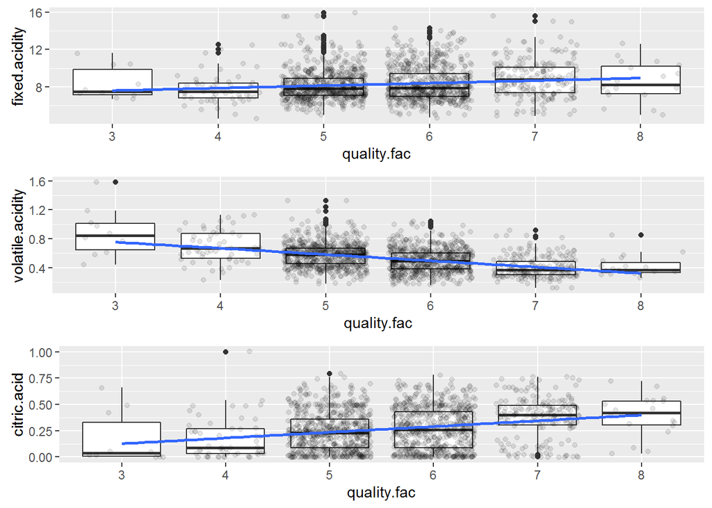

```
## df$quality: 3
##  fixed.acidity    volatile.acidity  citric.acid
##  Min.   : 6.700   Min.   :0.4400   Min.   :0.0000
##  1st Qu.: 7.150   1st Qu.:0.6475   1st Qu.:0.0050
##  Median : 7.500   Median :0.8450   Median :0.0350
##  Mean   : 8.360   Mean   :0.8845   Mean   :0.1710
##  3rd Qu.: 9.875   3rd Qu.:1.0100   3rd Qu.:0.3275
##  Max.   :11.600   Max.   :1.5800   Max.   :0.6600
## --------------------------------------------------------
## df$quality: 4
##  fixed.acidity    volatile.acidity  citric.acid
##  Min.   : 4.600   Min.   :0.230    Min.   :0.0000
##  1st Qu.: 6.800   1st Qu.:0.530    1st Qu.:0.0300
##  Median : 7.500   Median :0.670    Median :0.0900
##  Mean   : 7.779   Mean   :0.694    Mean   :0.1742
##  3rd Qu.: 8.400   3rd Qu.:0.870    3rd Qu.:0.2700
##  Max.   :12.500   Max.   :1.130    Max.   :1.0000
## --------------------------------------------------------
## df$quality: 5
##  fixed.acidity    volatile.acidity  citric.acid
##  Min.   : 5.000   Min.   :0.180    Min.   :0.0000
##  1st Qu.: 7.100   1st Qu.:0.460    1st Qu.:0.0900
##  Median : 7.800   Median :0.580    Median :0.2300
##  Mean   : 8.167   Mean   :0.577    Mean   :0.2437
##  3rd Qu.: 8.900   3rd Qu.:0.670    3rd Qu.:0.3600
##  Max.   :15.900   Max.   :1.330    Max.   :0.7900
## --------------------------------------------------------
## df$quality: 6
##  fixed.acidity    volatile.acidity  citric.acid
##  Min.   : 4.700   Min.   :0.1600   Min.   :0.0000
##  1st Qu.: 7.000   1st Qu.:0.3800   1st Qu.:0.0900
##  Median : 7.900   Median :0.4900   Median :0.2600
##  Mean   : 8.347   Mean   :0.4975   Mean   :0.2738
##  3rd Qu.: 9.400   3rd Qu.:0.6000   3rd Qu.:0.4300
##  Max.   :14.300   Max.   :1.0400   Max.   :0.7800
## --------------------------------------------------------
## df$quality: 7
##  fixed.acidity    volatile.acidity  citric.acid
##  Min.   : 4.900   Min.   :0.1200   Min.   :0.0000
##  1st Qu.: 7.400   1st Qu.:0.3000   1st Qu.:0.3050
##  Median : 8.800   Median :0.3700   Median :0.4000
##  Mean   : 8.872   Mean   :0.4039   Mean   :0.3752
##  3rd Qu.:10.100   3rd Qu.:0.4850   3rd Qu.:0.4900
##  Max.   :15.600   Max.   :0.9150   Max.   :0.7600
## --------------------------------------------------------
## df$quality: 8
##  fixed.acidity    volatile.acidity  citric.acid
##  Min.   : 5.000   Min.   :0.2600   Min.   :0.0300
##  1st Qu.: 7.250   1st Qu.:0.3350   1st Qu.:0.3025
##  Median : 8.250   Median :0.3700   Median :0.4200
##  Mean   : 8.567   Mean   :0.4233   Mean   :0.3911
##  3rd Qu.:10.225   3rd Qu.:0.4725   3rd Qu.:0.5300
##  Max.   :12.600   Max.   :0.8500   Max.   :0.7200
```

There is a clear trend that links the different acidity concentration with wine quality.

- the higher the citric acid concentration, the higher the wine quality ratings
- the lower the volatile acidity concentration, the higher the wine quality ratings
- the higher wine quality rating are more frequently coupled with high fixed acidity concentrations

## Density vs quality ratings

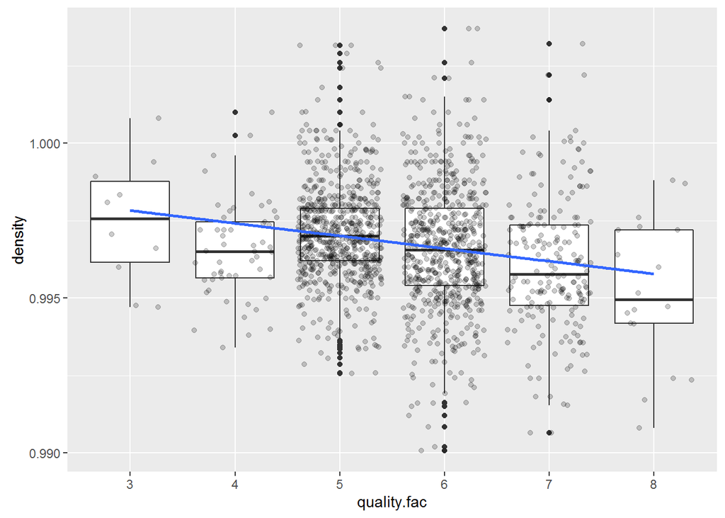

```
## df$quality: 3
##    Min. 1st Qu.  Median    Mean 3rd Qu.    Max.
##  0.9947  0.9962  0.9976  0.9975  0.9988  1.0010
## --------------------------------------------------------
## df$quality: 4
##    Min. 1st Qu.  Median    Mean 3rd Qu.    Max.
##  0.9934  0.9956  0.9965  0.9965  0.9974  1.0010
## --------------------------------------------------------
## df$quality: 5
##    Min. 1st Qu.  Median    Mean 3rd Qu.    Max.
##  0.9926  0.9962  0.9970  0.9971  0.9979  1.0030
## --------------------------------------------------------
## df$quality: 6
##    Min. 1st Qu.  Median    Mean 3rd Qu.    Max.
##  0.9901  0.9954  0.9966  0.9966  0.9979  1.0040
## --------------------------------------------------------
## df$quality: 7
##    Min. 1st Qu.  Median    Mean 3rd Qu.    Max.
##  0.9906  0.9948  0.9958  0.9961  0.9974  1.0030
## --------------------------------------------------------
## df$quality: 8
##    Min. 1st Qu.  Median    Mean 3rd Qu.    Max.
##  0.9908  0.9942  0.9949  0.9952  0.9972  0.9988
```

There seems to be a trend that negatively links the density with wine quality ratings:

- the higher the density, the lower the wine quality ratings

## Alcohol vs quality ratings

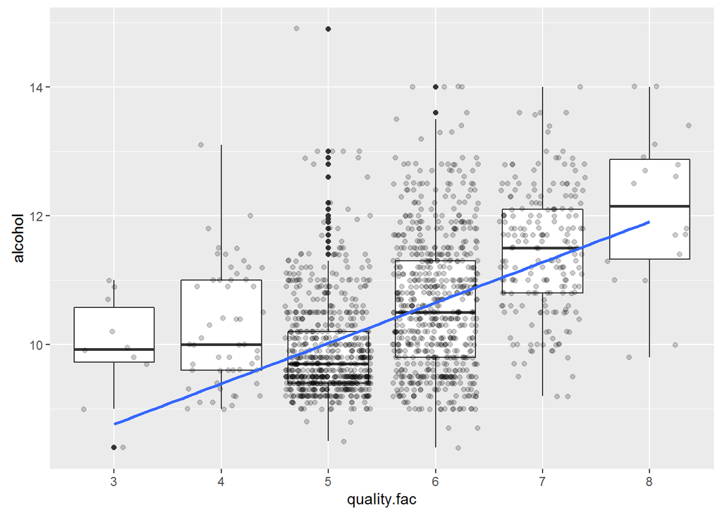

```
## df$quality: 3
##    Min. 1st Qu.  Median    Mean 3rd Qu.    Max.
##   8.400   9.725   9.925   9.955  10.580  11.000
## --------------------------------------------------------
## df$quality: 4
##    Min. 1st Qu.  Median    Mean 3rd Qu.    Max.
##    9.00    9.60   10.00   10.27   11.00   13.10
## --------------------------------------------------------
## df$quality: 5
##    Min. 1st Qu.  Median    Mean 3rd Qu.    Max.
##     8.5     9.4     9.7     9.9    10.2    14.9
## --------------------------------------------------------
## df$quality: 6
##    Min. 1st Qu.  Median    Mean 3rd Qu.    Max.
##    8.40    9.80   10.50   10.63   11.30   14.00
## --------------------------------------------------------
## df$quality: 7
##    Min. 1st Qu.  Median    Mean 3rd Qu.    Max.
##    9.20   10.80   11.50   11.47   12.10   14.00
## --------------------------------------------------------
## df$quality: 8
##    Min. 1st Qu.  Median    Mean 3rd Qu.    Max.
##    9.80   11.32   12.15   12.09   12.88   14.00
```

There seems to be a trend that positively links the alcohol concentration with wine quality ratings:

- the higher the alcohol level, the higher the wine quality ratings

## Sulphates vs quality ratings

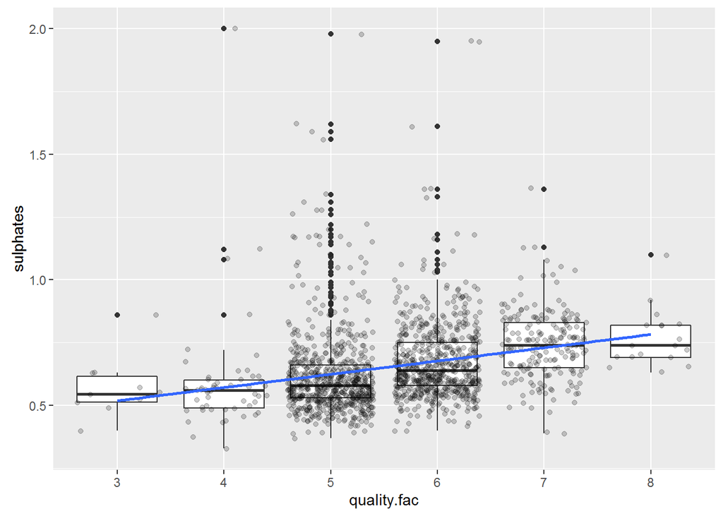

```
## df$quality: 3
##    Min. 1st Qu.  Median    Mean 3rd Qu.    Max.
##  0.4000  0.5125  0.5450  0.5700  0.6150  0.8600
## --------------------------------------------------------
## df$quality: 4
##    Min. 1st Qu.  Median    Mean 3rd Qu.    Max.
##  0.3300  0.4900  0.5600  0.5964  0.6000  2.0000
## --------------------------------------------------------
## df$quality: 5
##    Min. 1st Qu.  Median    Mean 3rd Qu.    Max.
##   0.370   0.530   0.580   0.621   0.660   1.980
## --------------------------------------------------------
## df$quality: 6
##    Min. 1st Qu.  Median    Mean 3rd Qu.    Max.
##  0.4000  0.5800  0.6400  0.6753  0.7500  1.9500
## --------------------------------------------------------
## df$quality: 7
##    Min. 1st Qu.  Median    Mean 3rd Qu.    Max.
##  0.3900  0.6500  0.7400  0.7413  0.8300  1.3600
## --------------------------------------------------------
## df$quality: 8
##    Min. 1st Qu.  Median    Mean 3rd Qu.    Max.
##  0.6300  0.6900  0.7400  0.7678  0.8200  1.1000
```

There seems to be a trend that positively links the sulphates concentration with wine quality ratings:

- the higher the sulphates concentration, the higher the wine quality ratings

## Acidity concentration vs pH

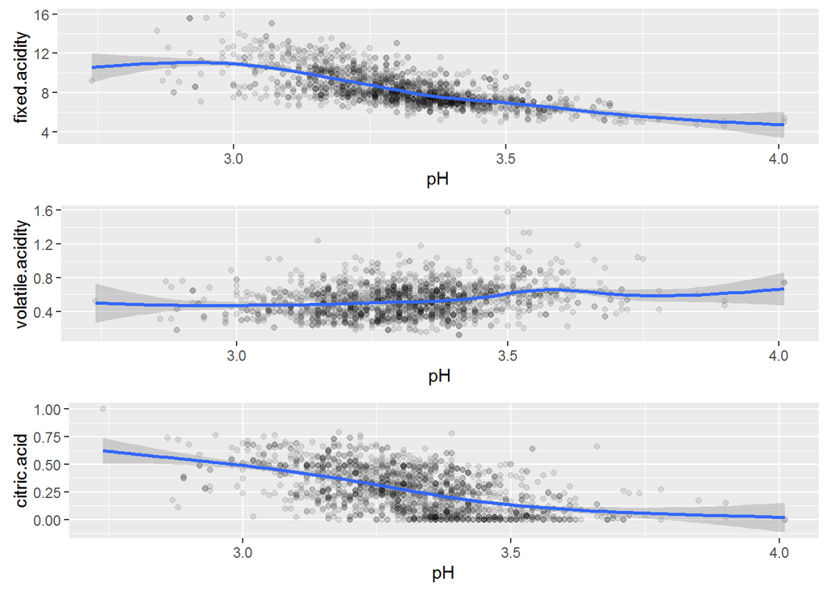

As we saw earlier, fixed acid and citric acid concentration seem to be correlated with pH level. They is a chance that they are ionised in the solution and generate H+ ions that reduces the pH level.

Volatile acidity, on the other hand, does not seem to play an important role on the pH level. Maybe the acid molecule is not ionized in the solution, or its acidity power is so weak that, under such concentration, it does not affect the pH level.

## Fixed acidity and citric acidity

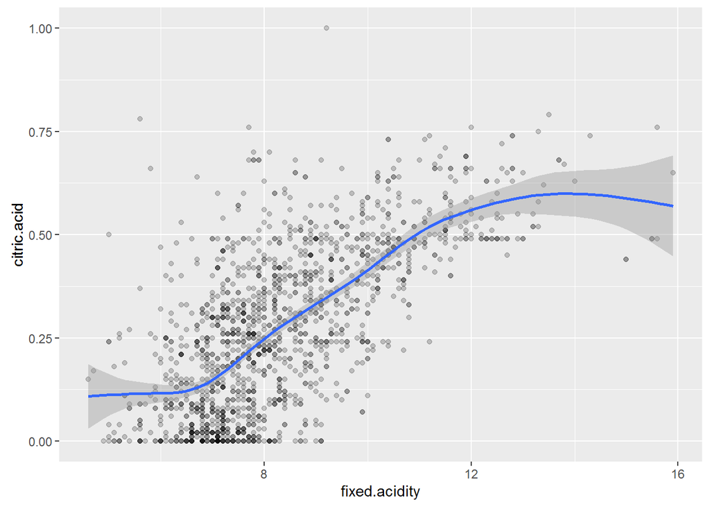

```
##
##  Pearson's product-moment correlation
##
## data:  df$fixed.acidity and df$citric.acid
## t = 36.234, df = 1597, p-value < 2.2e-16
## alternative hypothesis: true correlation is not equal to 0
## 95 percent confidence interval:
##  0.6438839 0.6977493
## sample estimates:
##       cor
## 0.6717034
```

As expected, citric acidity and fixed acidity are positively correlated. Maybe their generation is linked to similar chemical reactions.

## Fixed acidity and density

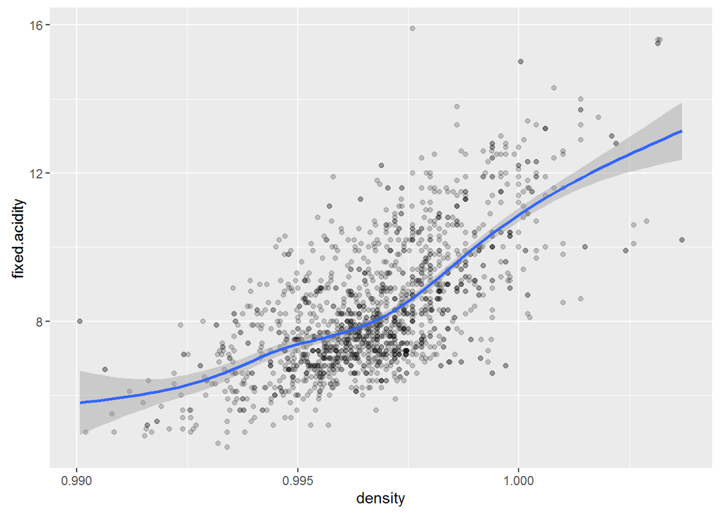

```
##
##  Pearson's product-moment correlation
##
## data:  df$fixed.acidity and df$density
## t = 35.877, df = 1597, p-value < 2.2e-16
## alternative hypothesis: true correlation is not equal to 0
## 95 percent confidence interval:
##  0.6399847 0.6943302
## sample estimates:
##       cor
## 0.6680473
```

As expected, density and fixed acidity are positively correlated. The fixed acids molecule must have a density than water, which could explain the lineral positive relation.

## Density vs Alcohol

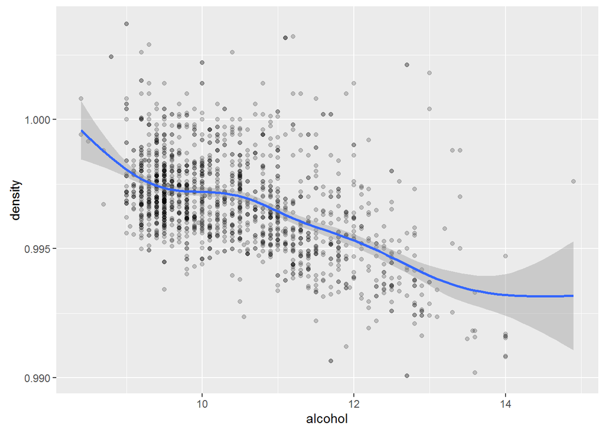

```
##
##  Pearson's product-moment correlation
##
## data:  df$alcohol and df$density
## t = -22.838, df = 1597, p-value < 2.2e-16
## alternative hypothesis: true correlation is not equal to 0
## 95 percent confidence interval:
##  -0.5322547 -0.4583061
## sample estimates:
##        cor
## -0.4961798
```

As expected, alcohol concentration and density are negatively correlated. As alcohol has a lower density than water, it makes sense that the more alcohol there is, the lower the density of the solution.

## Density vs Residual sugars

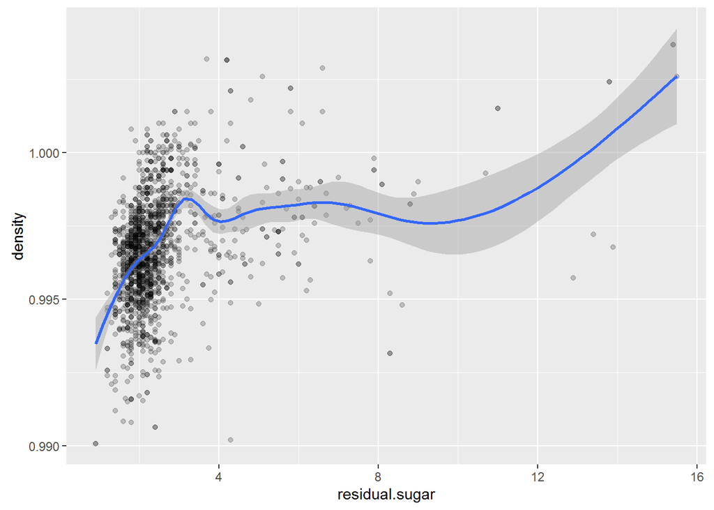

```
##
##  Pearson's product-moment correlation
##
## data:  df$residual.sugar and df$density
## t = 15.189, df = 1597, p-value < 2.2e-16
## alternative hypothesis: true correlation is not equal to 0
## 95 percent confidence interval:
##  0.3116908 0.3973835
## sample estimates:
##       cor
## 0.3552834
```

The correlation here is a bit more difficult to see, especialy in the densily populated area.

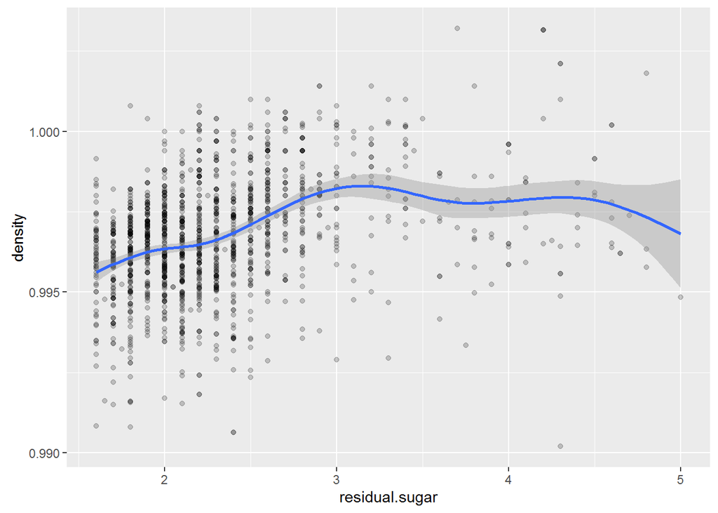

```
##
##  Pearson's product-moment correlation
##
## data:  residual.sugar and density
## t = 13.791, df = 1433, p-value < 2.2e-16
## alternative hypothesis: true correlation is not equal to 0
## 95 percent confidence interval:
##  0.2957896 0.3871868
## sample estimates:
##       cor
## 0.3422977
```

When focusing on the most frequent residual sugar observations, the correlation appears better on the chart.

## Chloride and sulfates ?

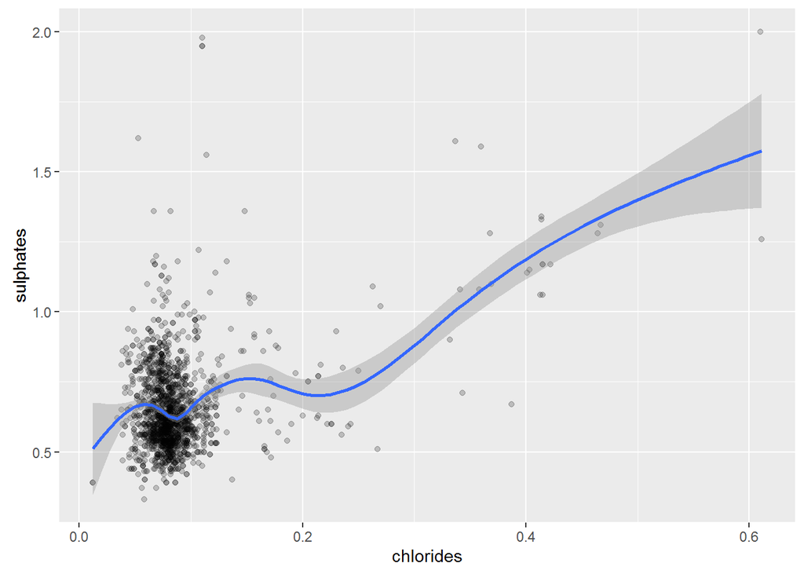

```
##
##  Pearson's product-moment correlation
##
## data:  df$chlorides and df$sulphates
## t = 15.978, df = 1597, p-value < 2.2e-16
## alternative hypothesis: true correlation is not equal to 0
## 95 percent confidence interval:
##  0.3282127 0.4127694
## sample estimates:
##       cor
## 0.3712605
```

The correlation here is difficult to see, especialy in the densily populated area. Let’s use a log10 transformation to see it clearer.

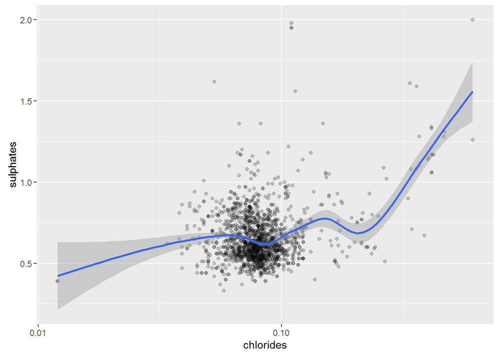

The correlation does not seem to be strong in the densely populated area. Let’s focus on observations within the 5% / 95% quantiles.

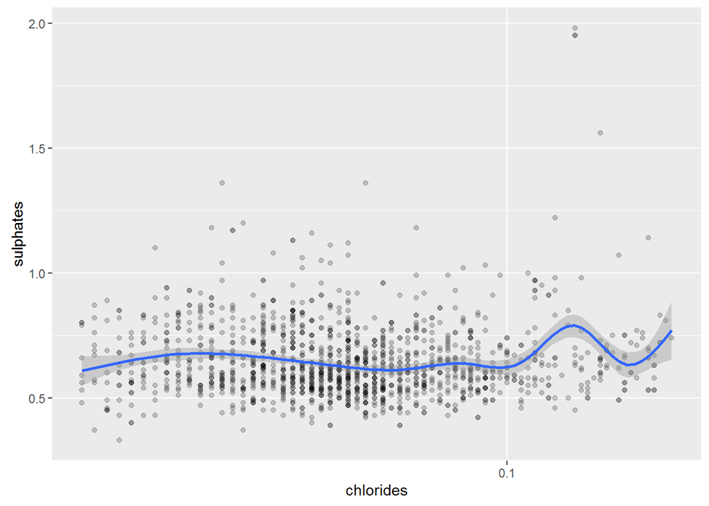

```
##
##  Pearson's product-moment correlation
##
## data:  chlorides and sulphates
## t = 0.82607, df = 1426, p-value = 0.4089
## alternative hypothesis: true correlation is not equal to 0
## 95 percent confidence interval:
##  -0.03003808  0.07366065
## sample estimates:
##        cor
## 0.02187011
```

In that case, when we focuse on the most frequent chlorides observations, it does not appear any significant correlation.The general correlation is then influenced by the most extreme observations.

# Bivariate Analysis

### Talk about some of the relationships you observed in this part of the investigation. How did the feature(s) of interest vary with other features in the dataset?

We could identify a strong correlation between quality rating and acidity concentrations. More precisely:

- the higher the citric acid concentration, the higher the wine quality ratings
- the lower the volatile acidity concentration, the higher the wine quality ratings
- the higher wine quality rating are more frequently coupled with high fixed acidity concentrations

The following features also show some relationship with the wine ratings: - Sulphates concentration (positive correlation) - Alcohol (positive correlation)

As alcohol and density are negatively correlated, we could also see a negative relation between density and wine quality ratings.

### Did you observe any interesting relationships between the other features (not the main feature(s) of interest)?

The following features showed interesting relationships:

- fixed acidity and pH (negative correlation)
- citric acid and pH (negative correlation)

This could have been expected, as the pH is a measure of acidity level (ionized H+).

- fixed acidity and citric acidity (positive correlation)
- fixed acidity and density (positive correlation)
- alcohol and density (negative correlation)
- residual sugars and density (positive correlation)
- total sulfur dioxyde and free sulfur dioxyde (positive correlation)

### What was the strongest relationship you found?

Alcohol level seem to play a major role on the wine quality ratings (Pearson correlation = 0.48).

# Multivariate Plots Section

The previous graphs were illustrating the different correlation existing between the different features. Let’s now have a look at how the different observations are distributed between 3 different features.

## Volatile acidity, Citric acidity and Wine quality class

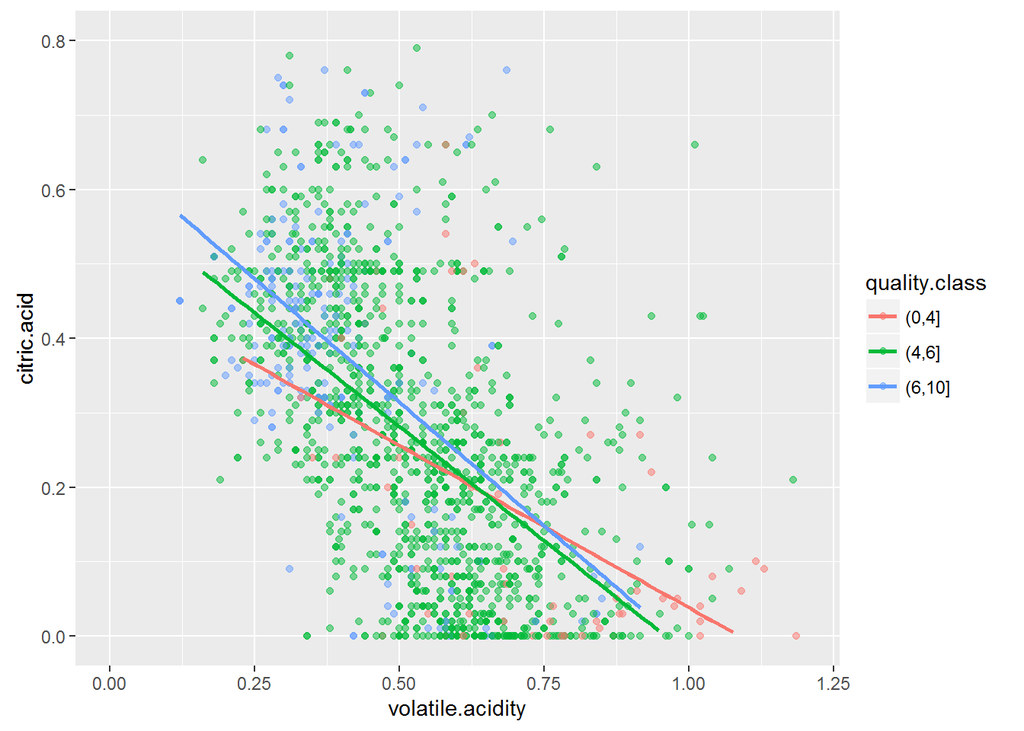

Most of the best rated wines are located in the upper left corner of the graph, which could have been expected, according to the correlations calculated in the previous chapter.

But there is no clear separation to see between the well rated wines and the others.

## Alcohol concentration, Sulphates and Wine quality class

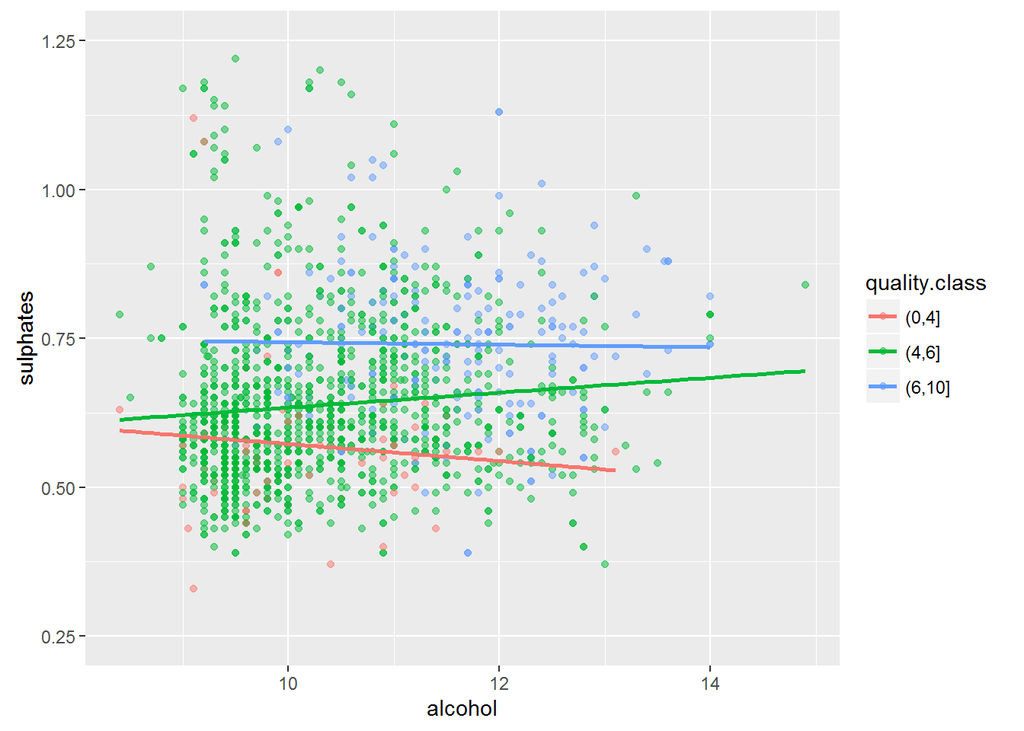

Most of the best rated wines are located in the upper right corner of the graph, which could have been expected, according to the correlations calculated in the previous chapter.

But there is no clear separation to see between the well rated wines and the others.

## Density, Residual sugars and Wine quality class

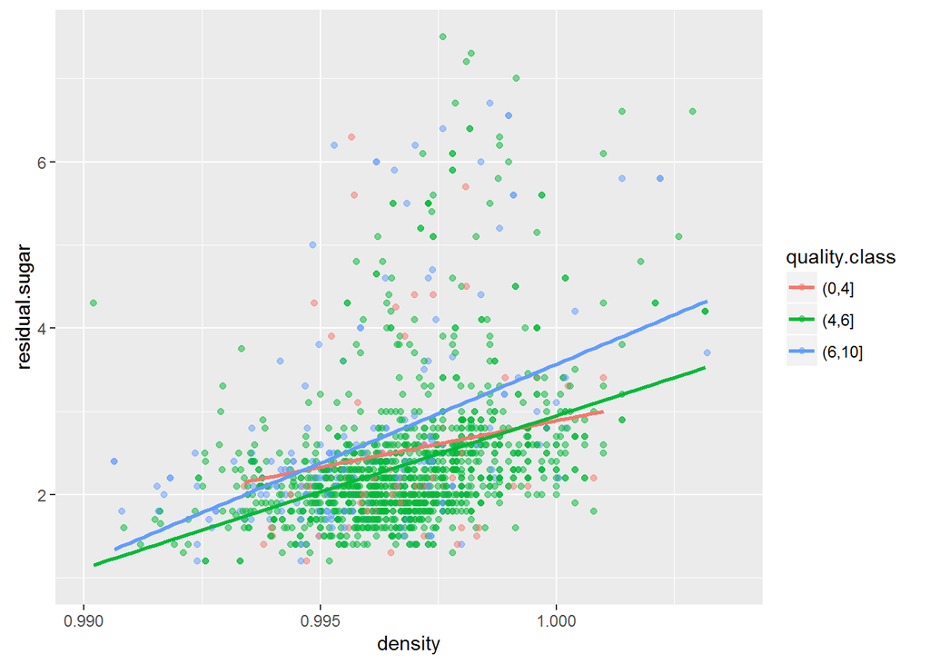

No clear distinction can be see here to split the good wines from the bad wines. This illustrates the relatively low correlation factors calculated in the previous chapter.

## Prediction model

As I don’t see other useful visualization to enhance the observations made in the previous chapters, I am focusing now on creating a linear model that could try to predict wine quality ratings based on the previous features.

```
##
## Calls:
## m1: lm(formula = quality ~ sulphates, data = df_train)
## m2: lm(formula = quality ~ sulphates + alcohol, data = df_train)
## m3: lm(formula = quality ~ sulphates + alcohol + density, data = df_train)
## m4: lm(formula = quality ~ sulphates + alcohol + density + citric.acid,
##     data = df_train)
## m5: lm(formula = quality ~ sulphates + alcohol + density + citric.acid +
##     volatile.acidity, data = df_train)
## m6: lm(formula = quality ~ sulphates + alcohol + density + citric.acid +
##     volatile.acidity + fixed.acidity, data = df_train)
##
## ==========================================================================================
##                        m1         m2          m3          m4          m5          m6
## ------------------------------------------------------------------------------------------
##   (Intercept)        4.809***   1.262***  -18.768       9.262     -20.057      22.618
##                     (0.103)    (0.226)    (13.796)    (15.272)    (15.026)    (18.851)
##   sulphates          1.234***   0.992***    0.946***    0.819***    0.595***    0.642***
##                     (0.152)    (0.134)     (0.137)     (0.140)     (0.136)     (0.136)
##   alcohol                       0.355***    0.374***    0.338***    0.339***    0.316***
##                                (0.021)     (0.024)     (0.026)     (0.025)     (0.025)
##   density                                  19.933      -7.883      22.541     -20.625
##                                           (13.727)    (15.188)    (14.975)    (18.892)
##   citric.acid                                           0.540***   -0.178      -0.482**
##                                                        (0.131)     (0.149)     (0.169)
##   volatile.acidity                                                 -1.257***   -1.254***
##                                                                    (0.140)     (0.139)
##   fixed.acidity                                                                 0.076***
##                                                                                (0.021)
## ------------------------------------------------------------------------------------------
##   R-squared              0.1       0.3         0.3         0.3         0.4         0.4
##   adj. R-squared         0.1       0.3         0.3         0.3         0.3         0.4
##   sigma                  0.8       0.7         0.7         0.7         0.6         0.6
##   F                     66.1     188.9       126.8       101.0       103.7        89.9
##   p                      0.0       0.0         0.0         0.0         0.0         0.0
##   Log-likelihood     -1108.7    -981.0      -980.0      -971.5      -932.4      -925.5
##   Deviance             566.9     434.4       433.4       425.8       392.5       386.9
##   AIC                 2223.4    1970.1      1970.0      1955.0      1878.7      1867.0
##   BIC                 2238.0    1989.5      1994.3      1984.2      1912.8      1905.9
##   N                    959       959         959         959         959         959
## ==========================================================================================
```

```
## Confusion Matrix and Statistics
##
##           Reference
## Prediction   3   4   5   6   7   8
##          3   0   0   4   1   0   0
##          4   0   0  12   7   0   0
##          5   0   0 197  67   1   1
##          6   0   0  88 164   6   0
##          7   0   0   7  61  14   0
##          8   0   0   0   8   2   0
##
## Overall Statistics
##
##                Accuracy : 0.5859
##                  95% CI : (0.5467, 0.6244)
##     No Information Rate : 0.4812
##     P-Value [Acc > NIR] : 6.966e-08
##
##                   Kappa : 0.3114
##  Mcnemar's Test P-Value : NA
##
## Statistics by Class:
##
##                      Class: 3 Class: 4 Class: 5 Class: 6 Class: 7 Class: 8
## Sensitivity                NA       NA   0.6396   0.5325  0.60870 0.000000
## Specificity          0.992188  0.97031   0.7922   0.7169  0.88979 0.984351
## Pos Pred Value             NA       NA   0.7406   0.6357  0.17073 0.000000
## Neg Pred Value             NA       NA   0.7032   0.6230  0.98387 0.998413
## Prevalence           0.000000  0.00000   0.4813   0.4813  0.03594 0.001563
## Detection Rate       0.000000  0.00000   0.3078   0.2562  0.02187 0.000000
## Detection Prevalence 0.007812  0.02969   0.4156   0.4031  0.12812 0.015625
## Balanced Accuracy          NA       NA   0.7159   0.6247  0.74924 0.492175
```

The accuracy on the test set is quite low (59%). This illustrates the difficulty to predict wine quality with these chemicals with a simple linear model.

# Multivariate Analysis

### Talk about some of the relationships you observed in this part of the investigation. Were there features that strengthened each other in terms of looking at your feature(s) of interest?

As expected, the best wines contain in general more citric acidity and less volatile acidity. They also contain more alcohol and sulphates.

But it is important to underline the fact that there is no clear separation that can be drawn from these features. There are always an unneglectable number of observations that show a high quality rating, with low alcohol concentration, sulphates concentration or citric acidity.

### Were there any interesting or surprising interactions between features?

I did not find any other interesting or surprising interactions.

### OPTIONAL: Did you create any models with your dataset? Discuss the strengths and limitations of your model.

I created a linear model out of the main features discussed above. As expected, it is difficult to predict accurately with a linear model the wine quality ratings. The accuracy obtained on the test set is only 58%.

Maybe another model could be useful to handle the low number of observations that can be used to train the model (SVM, decision tree, etc.).

# Final Plots and Summary

### Plot One

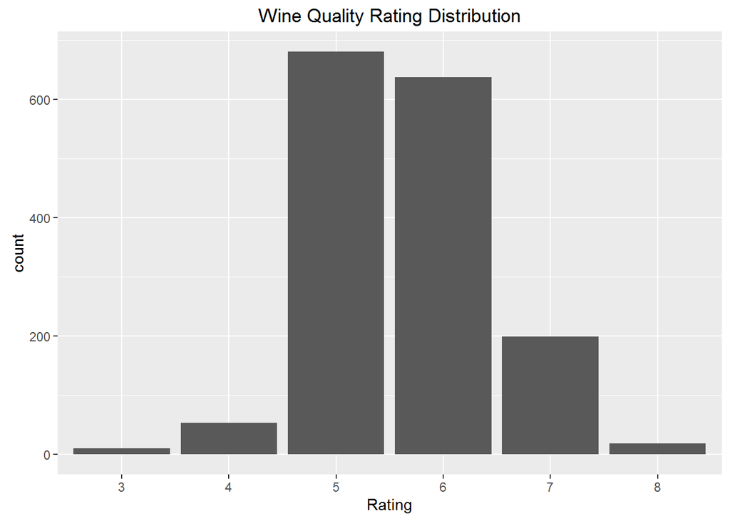

### Description One

This plot is important because it shows the distribution of the wine quality ratings. The distribution has a normal shape and it appears clearly that most of the ratings are between 5 and 6.

These ratings have been made by 3 different experts. As this is a subjective feature, it may bring some noise in the analysis. This can explain the difficulty to find clear trends between the different chemicals that are correlated with good or bad ratings.

### Plot Two

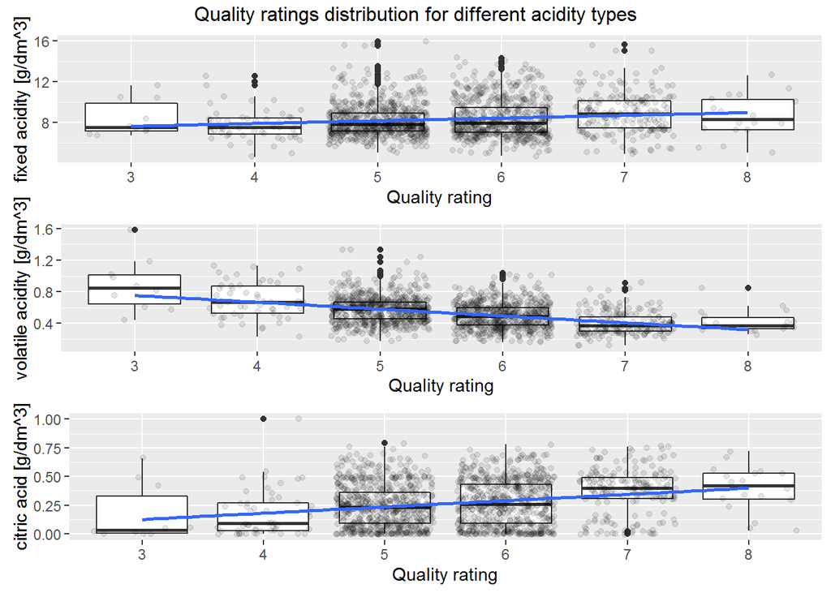

### Description Two

This plot shows in an easy way what is the general correlation between the different acidity concentration and the quality ratings.

It appears clearly that high quality ratings are generally correlated with high fixed and citric acidity and low volatile acidity.

### Plot Three

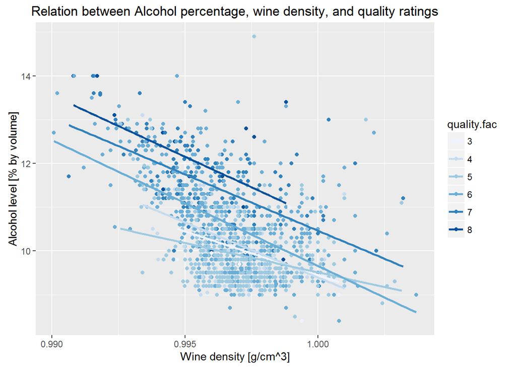

### Description Three

The previous plot shows the correlation between high alcohol concentration, low density and high wine quality ratings.

As alcohol is lighter than water, it appears that higher degrees of alcohol are correlated with lower densities. Similarly, we can see that a majority of high quality ratings are linked to high alcohol level, and by extension, low densities.

# Reflection

I first explored the different feature distributions in order to get an idea about the data. Most of the distribution were approximately normal. What struck me was that most of the ratings were between 5 and 6, which made it later difficult to distinguish clear correlation with the input features.

I then did a correlation matrix that helped me to identify the most visible correlation between the features. I replotted the ones that I found interesting and was then able to identify some clues about which chemicals may have an impact on the quality ratings.

I tried to look further with multivariate plots, but I did not find a lot of relevant additional information from it. I then built a linear model to try to predict wine ratings from the main chemicals that were correlated with it. My model accuracy on the test set was not very high (58%). But this illustrates the fact that there is no clear linear separation that can be drawn between good wines from bad ones only from this features. Maybe another type of algorithm could have better results (SVM, decision trees, etc.).

The main relations that I found were that the best wines were often correlated with:

- high citric acidity levels
- high fixed acidity levels
- low volatile acidity levels
- high alcohol levels
- high sulphates levels

But I found some limitations with these results. In general, the relations were quite noisy, and for each trend, a lot of counter-examples were to be noted. I believe that, as these ratings is a subjective feature depending on the experts’ taste, some noise must have been brought in the data.

Moreover, there is no info about the grape variety. Knowing which ratio of which grape variety has been used could be helpful to understand better the different trends identified in the previous EDA.

# Bibliography

- Udacity
- P. Cortez, A. Cerdeira, F. Almeida, T. Matos and J. Reis. Modeling wine preferences by data mining from physicochemical properties. In Decision Support Systems, Elsevier, 47(4):547-553. ISSN: 0167-9236.